# 1_Intro_Machine_Learning_1

### Check Duplicated Value

```python
# duplicate
diamonds.duplicated().sum()
```

```
0
```

> **Insight**: There is no duplicated values

### Handle Numerical Data: Outliers

The missing or outlier values are replaced with some value. This can be done using mean, median, or mode imputation, or by replacing the value with some other estimate such as interpolation.

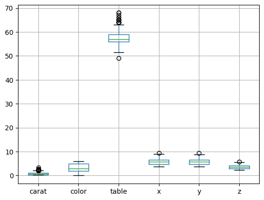

```python
diamonds.boxplot(column=num_features)
```

**Insight:** There are some outliers here. Different with previous case, we will not try replace/remove the outliers. Because, in some cases, removing or replacing outliers may not be the best approach. Outliers may represent genuine and meaningful data points that carry important information about the underlying distribution of the data. Removing or replacing these outliers may result in a biased or incomplete analysis of the data.

Instead, it may be more appropriate to leave the outliers as they are and adjust the analysis or model accordingly. For instance, we may consider using robust statistical methods that are less sensitive to outliers or implementing a separate analysis that focuses specifically on the outliers. It may also be useful to explore the reasons behind the presence of outliers and determine if they are the result of measurement error, data entry error, or other factors that may be addressed directly.

### Handle Categorical Data: Encoding

Many machine learning models cannot directly accept categorical columns as inputs, because they are designed to work with numerical data. Therefore, it is often necessary to convert categorical columns into numerical data using techniques like ordinal encoding, one-hot encoding, or other encoding methods.

To determine the appropriate encoding method, let's review our list of categories.

```python
for col in cat_features:
    print(diamonds[col].cat.categories)
```

```
Index(['Fair', 'Good', 'Ideal', 'Premium', 'Very Good'], dtype='object')
Index(['I1', 'IF', 'SI', 'VS', 'VVS'], dtype='object')
```

**Insight:** Based on the above result, what we need to do is perform ordinal encoding, as all the categorical data appears to be ordinal.

```python
diamonds['cut'] = diamonds['cut'].cat.rename_categories([0, 1, 4, 3, 2])
diamonds['clarity'] = diamonds['clarity'].cat.rename_categories([0, 4, 1, 2, 3])
```

```python
# check the encoding result
diamonds.head()
```

|  | carat | cut | color | clarity | table | price | x | y | z |
| --- | --- | --- | --- | --- | --- | --- | --- | --- | --- |
| 0 | 0.63 | 0 | 5 | 2 | 60.0 | 2011 | 5.41 | 5.31 | 3.52 |
| 1 | 2.00 | 0 | 0 | 1 | 55.0 | 11189 | 7.82 | 7.67 | 5.15 |
| 2 | 0.48 | 0 | 4 | 1 | 59.0 | 994 | 5.28 | 5.26 | 2.97 |
| 3 | 2.04 | 0 | 1 | 1 | 56.0 | 9802 | 7.80 | 7.77 | 5.19 |
| 4 | 0.71 | 0 | 0 | 1 | 61.0 | 1409 | 5.54 | 5.49 | 3.61 |

## Train-Test Splitting

We will split our dataset into train (80%) and test (20%)

```python
from sklearn.model_selection import train_test_split

X = diamonds['carat'].values.reshape(-1,1) # this is done if only 1 column
y = diamonds['price'].values

X_train, X_test, y_train, y_test = train_test_split(X, y, test_size = 0.2, random_state = 100)
```

## Standardization

`StandardScaler` is a preprocessing technique in machine learning that is used to standardize the scale of numeric features in a dataset. It transforms the data so that it has a mean of 0 and a standard deviation of 1.

The purpose of standard scaling is to bring all the features to a similar scale, which can be important for certain machine learning algorithms.

It has two important methods:

- `fit(X)`: This method takes the input data X, which is a two-dimensional array-like object or a pandas dataframe, and computes the mean and standard deviation of each feature in the data. These statistics are used to standardize the data in the transform() method.
- `transform(X)`: This method takes the input data X and standardizes the scale of each feature in the data using the mean and standard deviation computed by the fit() method. The standardized data is then returned as a new array-like object.

```python
sklearn.__version__
```

```
'1.5.0'
```

```python
from sklearn.preprocessing import StandardScaler
# create standar scaler object
diamonds_ss = StandardScaler()
```

```python
X_train = diamonds_ss.fit_transform(X_train)
X_train[:5]
```

```
array([[ 0.16193609],
       [ 1.67973482],
       [-0.62731924],
       [-1.03206557],
       [ 2.42851552]])
```

```python
# just use transform for data test
X_test = diamonds_ss.transform(X_test)
X_test[:5]
```

```
array([[-0.97135362],
       [-0.97135362],
       [-0.24281023],
       [ 0.20241073],
       [ 0.58691974]])
```

## Model Building

After all the data preparation processes are completed, it is now time for the 'machine' to learn with train data and be tested by test data.

Steps to build an SVM model.

1. First, import the SVM library.
2. Create a variable `model_svr` to store the result of the `SVR()` model.
3. Fit the model using train data.

```python
svr_model = svm.SVR()
svr_model.fit(X_train, y_train)
```

```
SVR()
```

## Model Evaluation: Mean Absolute Error (MAE)

To find out how good our model is, we can calculate the prediction error (error) with the evaluation metric. One of the most popular regression models is **Mean Absolute Error (MAE)**. With MAE, we calculate the average error of all predictions, after taking the absolute value of the error. *This prevents the error from canceling out each out when we add them up.*

Here is the mathematical function of the Mean Absolute Error:

$$MAE = \frac{\sum_{i=1}^{n}\left | y_{pred, i} - y_{real, i} \right |}{n}$$

To compute the *Mean Absolute Error*, we can import scikit-learn's `mean_absolute_error` function.

```python
from sklearn.metrics import mean_absolute_error
```

```python
print("SVR Model (MAE)")
print("  Train:", mean_absolute_error(svr_model.predict(X_train), y_train))
print("  Test:", mean_absolute_error(svr_model.predict(X_test), y_test))
```

```
SVR Model (MAE)
  Train: 2521.8176363461835
  Test: 2076.416387203259
```

How to make checking the `mean_absolute_error` more concise every time?

**Opsional:** custom function to print_mae_train_test dari model dari data estate

```python
def print_mae_train_test(model):
    print(type(model).__name__,"Model (MAE)")
    print("  Train:", mean_absolute_error(model.predict(X_train), y_train))
    print("  Test:", mean_absolute_error(model.predict(X_test), y_test))
```

```python
print_mae_train_test(svr_model)
```

```
SVR Model (MAE)
  Train: 2521.8176363461835
  Test: 2076.416387203259
```

## Model Prediction

The `.predict()` method allows us to predict the labels of a new dataset using a trained model. This method takes only one argument (new data) and returns values (labels for classification) learned for each of its objects. The parameter provided is:

- `X`: The data to be predicted, typically `X_test` in general.

```python
est_y_pred = svr_model.predict(X_test)
est_y_pred[:5]
```

```
array([1921.99725413, 1921.99725413, 2474.70921389, 2978.04240277,
       3227.63774488])
```

```python
y_test[:5]
```

```
array([ 686,  596, 3354, 3709, 3854], dtype=int64)
```

## [Optional] Visualization

Let's visualize our model to get a visual idea of how our model fits the data. We do this by creating the `create_plot` function — the details of this function are optional because our focus is on model description.

```python
# a simple custom plotting utility (regression)
from helper import create_plot_svr, create_plot_svr_2_model
```

Let's visualize and compare our two models fit with the data.

```python
create_plot_svr(diamonds, svr_model)
```

[output not shown]

## Model Improvement: Tuning Hyperparameters SVR

Let's now dive into the hyperparameters that can affect the model performance of our Support Vector Regressor.

### Reguralization (C)

Reguralization (C) in SVR affects how our algorithm minimizes the error. The algorithm respond to an increase in C by capturing more points inside the epsilon-tube. Consequently, the algorithm will fit the data better.

While increasing C allows us to fit the data better, it also makes our model less robust, risking overfitting. Hence, it is best to be cautious when tuning hyperparameters and split the data into training and testing datasets so we can evaluate our model with unseen data.

#### Tuning `kernel='rbf', C=100`

```python
svr_model_tuned = svm.SVR(kernel='rbf', C=100)
svr_model_tuned.fit(X_train, y_train)

create_plot_svr_2_model(diamonds, svr_model, svr_model_tuned)
```

[output not shown]

**Insight:** It turns out that the results are very good with large C values, where the data fit is better, but care needs to be taken to ensure this does not expose the model to the risk of overfitting

```python
print_mae_train_test(svr_model)

print("\nAfter Tuning (kernel='rbf', C=100)")
print_mae_train_test(svr_model_tuned)
```

```
SVR Model (MAE)
  Train: 2521.8176363461835
  Test: 2076.416387203259

After Tuning (kernel='rbf', C=100)
SVR Model (MAE)
  Train: 905.6426697762688
  Test: 757.0628225574152
```

#### Tuning `kernel='rbf', C=0.01`

```python
svr_model_tuned2 = svm.SVR(kernel='rbf', C=0.01)
svr_model_tuned2.fit(X_train, y_train)

create_plot_svr_2_model(diamonds, svr_model, svr_model_tuned2)
```

[output not shown]

```python
print_mae_train_test(svr_model)

print("\nAfter Tuning (kernel='rbf', C=0.01)")
print_mae_train_test(svr_model_tuned2)
```

```
SVR Model (MAE)
  Train: 2521.8176363461835
  Test: 2076.416387203259

After Tuning (kernel='rbf', C=0.01)
SVR Model (MAE)
  Train: 2997.6202190039307
  Test: 2545.303177879529
```

**Insight:** The model increasingly does not follow the data pattern

> **NOTES**:
> - When C is large, then SVM will follow more data patterns (meandering), the results for this case are getting better (provided that the case is that the majority of the data is not far from the average data set)
> - When the C is small, it will be straighter/doesn't really follow the data pattern. And if it's too small, the error can be even bigger (C is small, there's a good chance, if our data has a complex pattern, a lot of the data is far from the average)

### Kernel

Alternative kernels in SVR are actually the same as those in SVM for classification, namely linear, rbf, and polymonial. Then also that basically the **best match** kernel with this data is `rbf`.

[figure not shown]

**Insight:** The `rbf` kernel works well in practice and is relatively easy to calibrate (the most flexible), in contrast to other kernels.